# Term_Project - AMOD 5250H

Neha Deshmukh

release date: 5th December 2018

## Data Summary

The data that is chosen for doing R analysis is the 2016 American Community Survey (ACS) 5-year Public Use Microdata Samples (PUMS). These are the actual responses that are taken by the ACS community. The data is divided into population data and household data.

For all the analysis done in this document, the **household** data is used. The household data contains information about various household characteristics and the types of households. The variables that this analysis uses are as follows,

- RT : Record Type  
  It specifies whether the household is a housing record(H) or a Group Quarters(GQ) Unit.
- SERIALNO : Serial Number  
  It is the housing Unit/GQ person serial number.It is a unique identifier.
- ADJHSG : Adjustment Factor for housing dollar amounts.  
  The adjustment factors are,  
  1045360 .2012 factor  
  1030392 .2013 factor  
  1013801 .2014 factor  
  1012636 .2015 factor  
  1000000 .2016 factor
- NP : Number of people associated with the housing record.  
  00 .Vacant unit  
  01 .One person record (one person in household or any person .in group quarters)  
  02..20 .Number of person records (number of persons in household)
- ACR : lot size  
  b .N/A (GQ/not a one-family house or mobile home)  
  1 .House on less than one acre  
  2 .House on one to less than ten acres  
  3 .House on ten or more acres
- BATH : Bathroom or shower.  
  b .N/A (GQ)  
  1 .Yes  
  2 .No
- BDSP : Number of bedrooms.  
  bb .N/A (GQ)  
  00..99 .0 to 99 bedrooms
- ELEP : monthly Electricity cost  
  bbb .N/A (GQ/vacant)  
  001 .Included in rent or in condo fee  
  002 .No charge or electricity not used  
  003..999 .$3$ to $999$
- REFR : Refrigerator  
  b .N/A (GQ)  
  1 .Yes  
  2 .No
- RMSP : Number of Rooms  
  bb .N/A (GQ)  
  00..99 .Rooms
- WATP : Yearly water cost  
  bbbb .N/A (GQ/vacant)  
  0001 .Included in rent or in condo fee  
  0002 .No charge  
  0003..9999 .$3$ to $9999$
- RWAT : hot and cold running water  
  b .N/A (GQ)  
  1 .Yes  
  2 .No  
  9 .Case is from Puerto Rico in 2013 or later, RWAT not applicable

Let us now import the data that the analysis will be using.

```r
h_abcd <- fread("E:/neha/studies/trent study material/Data Analysis with R/housing_all.csv")
head(h_abcd)
```

| V1 | RT | SERIALNO | ADJHSG | NP | ACR | BATH | BDSP | ELEP | WATP | REFR | RMSP | RWAT |
| --- | --- | --- | --- | --- | --- | --- | --- | --- | --- | --- | --- | --- |
| 1 | H | 2012000000001 | 1045360 | 2 | 1 | 1 | 3 | 120 | 600 | 1 | 8 | 1 |
| 2 | H | 2012000000002 | 1045360 | 1 | 2 | 1 | 3 | 60 | 220 | 1 | 6 | 1 |
| 3 | H | 2012000000003 | 1045360 | 1 | NA | 1 | 1 | 20 | 2 | 1 | 3 | 1 |
| 4 | H | 2012000000004 | 1045360 | 1 | 1 | 1 | 2 | 30 | 20 | 1 | 5 | 1 |
| 5 | H | 2012000000005 | 1045360 | 1 | 1 | 1 | 3 | 80 | 560 | 1 | 5 | 1 |
| 6 | H | 2012000000006 | 1045360 | 4 | 1 | 1 | 3 | 100 | 800 | 1 | 6 | 1 |

First, we change the variables BATH, REFR and RWAT to factor variables with levels as 0, 1.

```r
h_abcd$BATH <- factor(h_abcd$BATH, levels=c(0,1))
h_abcd$REFR <- factor(h_abcd$REFR, levels=c(0,1))
h_abcd$RWAT <- factor(h_abcd$RWAT, levels=c(0,1))
str(h_abcd)
```

```
## Classes 'data.table' and 'data.frame':   7439832 obs. of  13 variables:
##  $ V1      : int  1 2 3 4 5 6 7 8 9 10 ...
##  $ RT      : chr  "H" "H" "H" "H" ...
##  $ SERIALNO:integer64 2012000000001 2012000000002 2012000000003 2012000000004 2012000000005 2012000000006 2012000000007 2012000000008 ...
##  $ ADJHSG  : int  1045360 1045360 1045360 1045360 1045360 1045360 1045360 1045360 1045360 1045360 ...
##  $ NP      : int  2 1 1 1 1 4 1 3 2 11 ...
##  $ ACR     : int  1 2 NA 1 1 1 1 1 1 3 ...
##  $ BATH    : Factor w/ 2 levels "0","1": 2 2 2 2 2 2 2 2 2 2 ...
##  $ BDSP    : int  3 3 1 2 3 3 3 3 3 4 ...
##  $ ELEP    : int  120 60 20 30 80 100 60 30 160 160 ...
##  $ WATP    : int  600 220 2 20 560 800 420 150 960 2 ...
##  $ REFR    : Factor w/ 2 levels "0","1": 2 2 2 2 2 2 2 2 2 2 ...
##  $ RMSP    : int  8 6 3 5 5 6 6 6 10 9 ...
##  $ RWAT    : Factor w/ 2 levels "0","1": 2 2 2 2 2 2 2 2 2 2 ...
##  - attr(*, ".internal.selfref")=<externalptr>
```

Now we do a summary of the data that we have using the **summary** function.

```r
summary(h_abcd)
```

```
##        V1               RT               SERIALNO
##  Min.   :      1   Length:7439832     Min.   :2012000000001
##  1st Qu.:1859959   Class :character   1st Qu.:2013000387215
##  Median :3719916   Mode  :character   Median :2014000775089
##  Mean   :3719916                      Mean   :2014011015328
##  3rd Qu.:5579874                      3rd Qu.:2015001154428
##  Max.   :7439832                      Max.   :2016001521446
##
##      ADJHSG              NP              ACR            BATH
##  Min.   :1000000   Min.   : 0.000   Min.   :1.0       0   :      0
##  1st Qu.:1012636   1st Qu.: 1.000   1st Qu.:1.0       1   :6630075
##  Median :1013801   Median : 2.000   Median :1.0       NA's: 809757
##  Mean   :1020333   Mean   : 2.108   Mean   :1.3
##  3rd Qu.:1030392   3rd Qu.: 3.000   3rd Qu.:2.0
##  Max.   :1045360   Max.   :20.000   Max.   :3.0
##                                     NA's   :2158451
##       BDSP             ELEP              WATP           REFR
##  Min.   : 0.0     Min.   :  1.0     Min.   :   1.0    0   :      0
##  1st Qu.: 2.0     1st Qu.: 70.0     1st Qu.:   2.0    1   :6577357
##  Median : 3.0     Median :120.0     Median : 220.0    NA's: 862475
##  Mean   : 2.8     Mean   :137.2     Mean   : 404.7
##  3rd Qu.: 3.0     3rd Qu.:180.0     3rd Qu.: 640.0
##  Max.   :19.0     Max.   :660.0     Max.   :4600.0
##  NA's   :742695   NA's   :1343723   NA's   :1343723
##       RMSP          RWAT
##  Min.   : 1       0   :      0
##  1st Qu.: 4       1   :6588418
##  Median : 6       NA's: 851414
##  Mean   : 6
##  3rd Qu.: 7
##  Max.   :30
##  NA's   :742695
```

A visual representation is always a help to better understand the data. Here, we use the **VIM** package to visually analyse the proportion of missing data and how much complete data we actually have. For this, we use the function **aggr** in VIM which makes a plot of missing data according to the variable names.

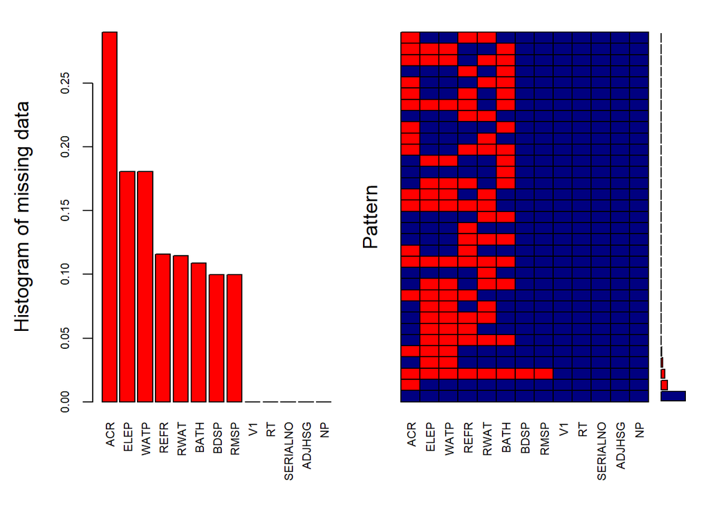

```
##
##  Variables sorted by number of missings:
##  Variable      Count
##       ACR 0.29012093
##      ELEP 0.18061201
##      WATP 0.18061201
##      REFR 0.11592668
##      RWAT 0.11443995
##      BATH 0.10884076
##      BDSP 0.09982685
##      RMSP 0.09982685
##        V1 0.00000000
##        RT 0.00000000
##  SERIALNO 0.00000000
##    ADJHSG 0.00000000
##        NP 0.00000000
```

```r
aggr_plot <- aggr(h_abcd, col=c('navyblue','red'), numbers=TRUE, sortVars=TRUE, labels=names(h_abcd), cex.axis=.7, gap=3, ylab=c("Histogram of missing data","Pattern"))
```

The above plot and the table show that we have about **29% missing values in ACR, 18% data missing in ELEP, 18% missing data in WATP** variable and so on. We handle these missing values in the methodology section.

Now we plot boxplots of the number of people, the number of rooms and the number of bedrooms data.

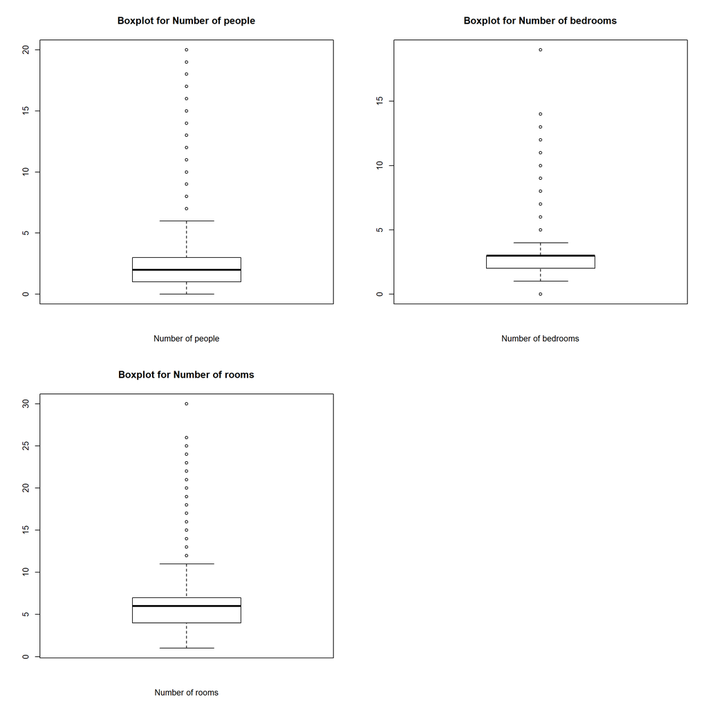

```r
par(mfrow = c(2,2))
boxplot(h_abcd$NP, main = "Boxplot for Number of people", xlab="Number of people")
boxplot(h_abcd$BDSP, main = "Boxplot for Number of bedrooms", xlab="Number of bedrooms")
boxplot(h_abcd$RMSP, main = "Boxplot for Number of rooms", xlab="Number of rooms")
```

The boxplots suggests that all the concerned variables have outliers which will be dealt with in the methodology section. Also, the boxplot for the number of people is nicely symmetric around the median. The number of bedrooms data have the median and the third quartile as same. This suggests a strong left skew in the data for the number of bedrooms. Likewise, the number of rooms boxplot suggests that there is a left skew in that data as well though not as strong as the number of bedrooms data.

Now, let’s look at some **histograms** for the **cost of electricity and water**.

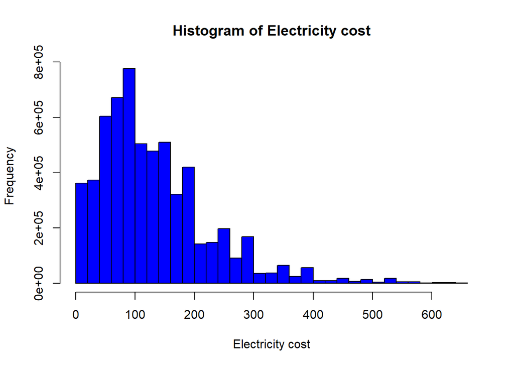

```r
hist(h_abcd$ELEP, main = "Histogram of Electricity cost", xlab="Electricity cost", ylab="Frequency", col = "Blue")
```

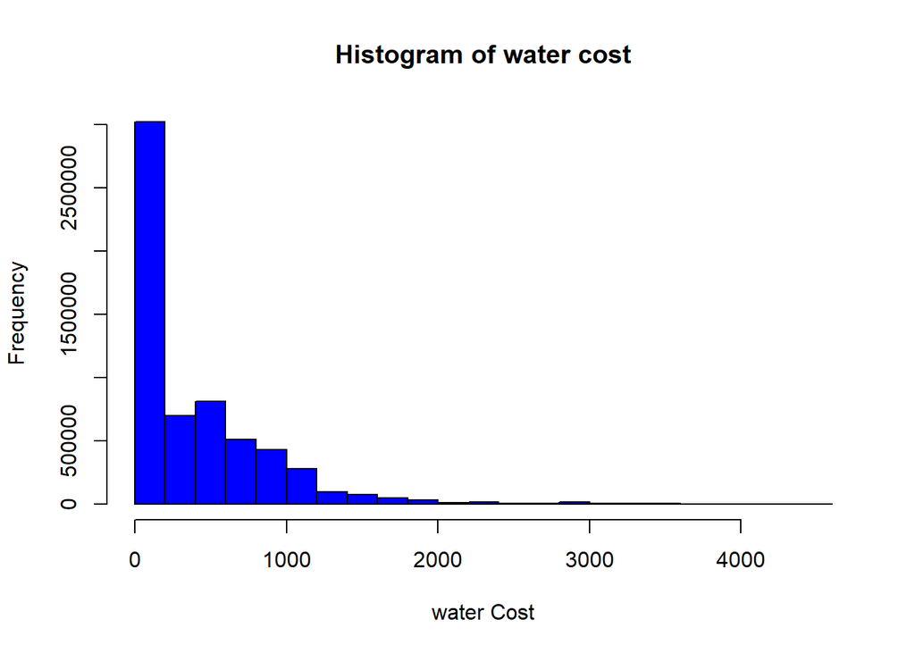

```r
hist(h_abcd$WATP, main = "Histogram of water cost", xlab = "water Cost", ylab="Frequency", col = "Blue")
```

Looking at the **histogram of Electricity Cost**, it is seen that the data is skewed towards the right. Most of the people pay within the range of 80 to 100 dollars for a month of electricity. The **histogram of Water Cost** suggests that over 30 lakh people pay between 0 to 200 dollars per year for water. This data is heavily skewed to the right.

## Methodology

As we saw in the graph of missing values in the summary section above, there are several variables which are missing the values. Out of them, ACR variable has the most missing values. Now, that we know there are many missing values, we will filter out rows containing these missing values as follows,

```r
h_abcd <- h_abcd %>%
  filter(!is.na(ACR) & !is.na(ELEP) & !is.na(WATP) & !is.na(REFR) & !is.na(RMSP) & !is.na(BATH) & !is.na(BDSP) & !is.na(RWAT))
head(h_abcd)
```

|  | V1 | RT | SERIALNO | ADJHSG | NP | ACR | BATH | BDSP | ELEP | WATP | REFR | RMSP | RWAT |
| --- | --- | --- | --- | --- | --- | --- | --- | --- | --- | --- | --- | --- | --- |
| 1 | 1 | H | 2012000000001 | 1045360 | 2 | 1 | 1 | 3 | 120 | 600 | 1 | 8 | 1 |
| 2 | 2 | H | 2012000000002 | 1045360 | 1 | 2 | 1 | 3 | 60 | 220 | 1 | 6 | 1 |
| 3 | 4 | H | 2012000000004 | 1045360 | 1 | 1 | 1 | 2 | 30 | 20 | 1 | 5 | 1 |
| 4 | 5 | H | 2012000000005 | 1045360 | 1 | 1 | 1 | 3 | 80 | 560 | 1 | 5 | 1 |
| 5 | 6 | H | 2012000000006 | 1045360 | 4 | 1 | 1 | 3 | 100 | 800 | 1 | 6 | 1 |
| 6 | 7 | H | 2012000000007 | 1045360 | 1 | 1 | 1 | 3 | 60 | 420 | 1 | 6 | 1 |

In this way, we have filtered out all the rows in the dataset that had missing values by using the **filter** function from **dplyr**.But Doing this has certain problems. We are doing analysis on only partial data. So whatever results we get from this data may be entirely different than what would we have gotten if the data were complete. So this method might skew the analysis. But since we have majority of the data with us for analysis, we use this method to handle the missing values.

As we have seen in the boxplots in the summary section, there are many outliers in the data of the number of people, number of bedrooms and the number of rooms variables. We find the extreme values in each of the attributes by using the **outlier function** in the **outliers** package as given below and then make a barplot of it,

```r
out <- c(outlier(h_abcd$NP),outlier(h_abcd$ACR),
              outlier(h_abcd$BDSP),
              outlier(h_abcd$RMSP),outlier(h_abcd$ELEP), outlier(h_abcd$WATP))
#Making a matrix of the outliers with their corresponding
mat.out <- matrix(data=out, nrow=1, ncol=6, byrow=TRUE)
rownames(mat.out) <- c("Extreme outlier")
colnames(mat.out) <- c("NP", "ACR", "BDSP", "RMSP", "ELEP", "WATP")
mat.out
```

```
##                 NP ACR BDSP RMSP ELEP WATP
## Extreme outlier 20   3   19   30  660 4600
```

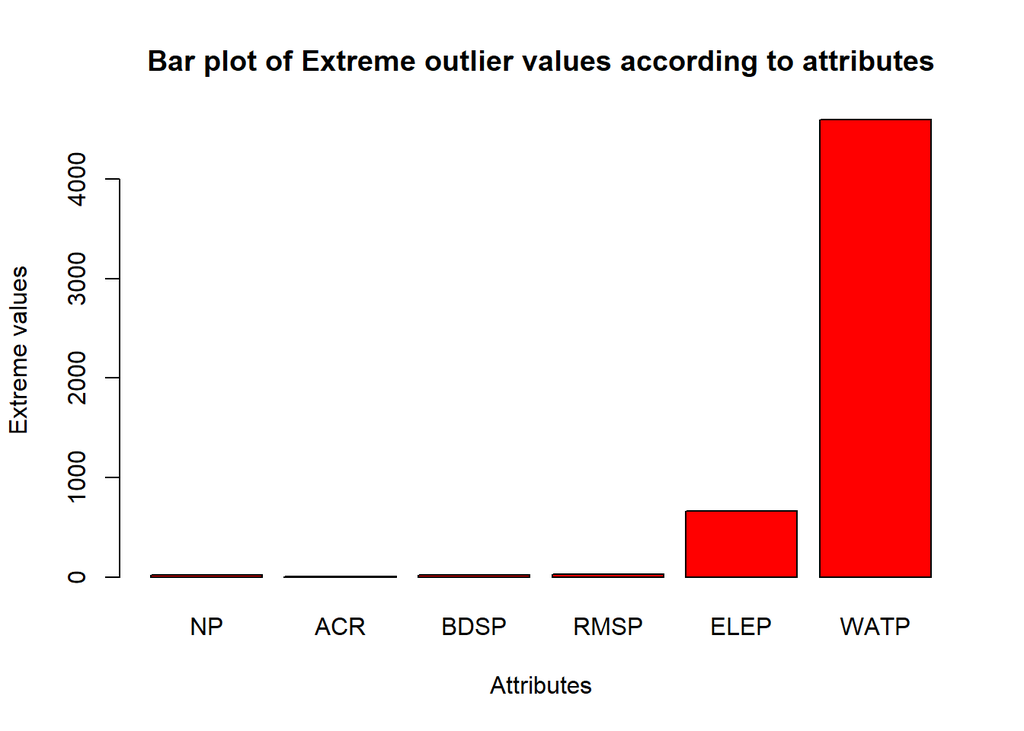

```r
#Making a bar plot of the matrix
barplot(mat.out, col="RED", main="Bar plot of Extreme outlier values according to attributes", xlab="Attributes", ylab="Extreme values")
```

The above bar plot gives the outlier values for the concerned variables. It shows that the outlier values for NP is 20 and so on. Now that we have some understanding of the outliers, we now replace the extreme values as outliers by the median by using the **rm.outlier** in the **outliers** package.

```r
h_abcd$NP <- rm.outlier(h_abcd$NP, fill=TRUE, median=TRUE, opposite=FALSE)
h_abcd$ACR <- rm.outlier(h_abcd$ACR, fill=TRUE, median=TRUE, opposite=FALSE)
h_abcd$BDSP <- rm.outlier(h_abcd$NP, fill=TRUE, median=TRUE, opposite=FALSE)
h_abcd$ELEP <- rm.outlier(h_abcd$ELEP, fill=TRUE, median=TRUE, opposite=FALSE)
h_abcd$WATP <- rm.outlier(h_abcd$WATP, fill=TRUE, median=TRUE, opposite=FALSE)
h_abcd$RMSP <- rm.outlier(h_abcd$RMSP, fill=TRUE, median=TRUE, opposite=FALSE)
```

Hence, we have replaced the extreme values by the median. Since, median is not affected by the outliers, it is a good approach to replace outliers with median instead of mean because mean is affected by the outliers. So replacing the outliers with mean affects the mean of the entire dataset and skews the results drastically. So we replaced the outliers with median in our analysis.

We examine the boxplot of the number of bedrooms without and compare it with the previous boxplot with outliers. Referring the above boxplot,

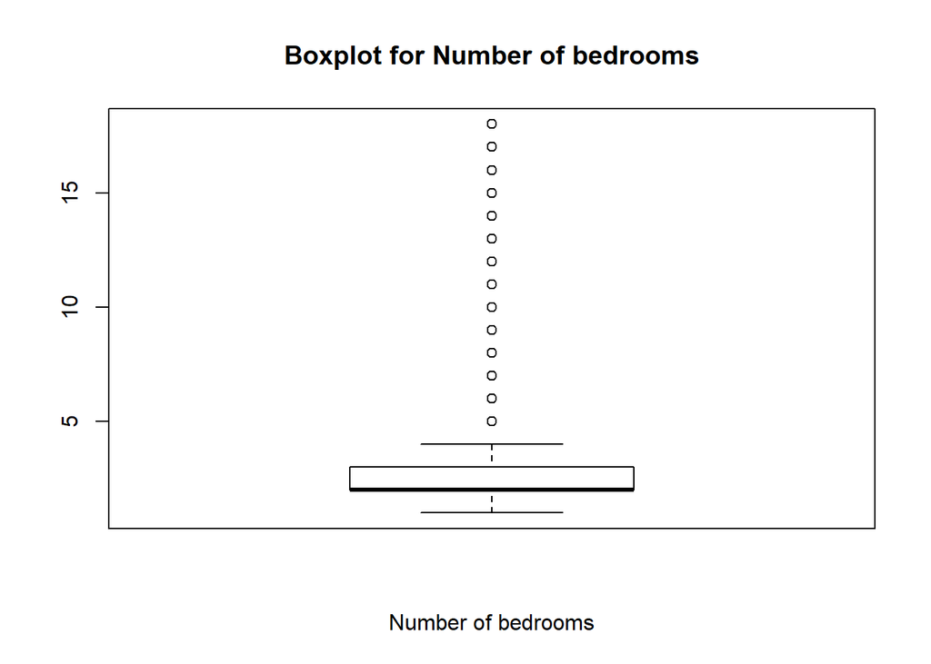

```r
boxplot(h_abcd$BDSP, main = "Boxplot for Number of bedrooms", xlab="Number of bedrooms")
```

Looking at the boxplot, it is seen that the outlier which was at the bottom of the plot earlier has been replaced with the median. Also, the one extreme point on the upper center of the plot has also been replaced likewise. Now the data has become right skewed now because the median has become almost similar to the 1st quartile.

Now that we have handled outliers and the missing values, we have to adjust the cost of electricity and water using the **ADJHSG** variable in the data. This is because the data is collected over the 5 years and hence we have to adjust the dollar values for the inflation. We do this adjustment by multiplying the values in the ADJHSG variable with the ELEP and WATP data respectively.

```r
#Making a new variable ELEP_A and WATP_A which are the adjusted amounts
h_abcd <- h_abcd %>%
  mutate(ELEP_A = ADJHSG * ELEP,
         WATP_A = ADJHSG * WATP)
head(select(h_abcd, ADJHSG, ELEP, ELEP_A, WATP, WATP_A))
```

|  | ADJHSG | ELEP | ELEP_A | WATP | WATP_A |
| --- | --- | --- | --- | --- | --- |
| 1 | 1045360 | 120 | 125443200 | 600 | 627216000 |
| 2 | 1045360 | 60 | 62721600 | 220 | 229979200 |
| 3 | 1045360 | 30 | 31360800 | 20 | 20907200 |
| 4 | 1045360 | 80 | 83628800 | 560 | 585401600 |
| 5 | 1045360 | 100 | 104536000 | 800 | 836288000 |
| 6 | 1045360 | 60 | 62721600 | 420 | 439051200 |

Now that we have handled the missing values and the outliers and adjusted the dollar amounts according to yearly inflation, we will now try to find some interesting relationships between the variables in the dataset.

We now do a **t statistical test** on the variables giving the cost of electricity and water to check if the costs are approximately similar. We do this by using the **t.test** function in R. It has the null hypothesis as **The two samples do not have a significant difference in the mean** and alternate hypothesis as **The two samples have a significant difference in their mean**. We check the significance using the 5% significance level.

```r
t.test(h_abcd$ELEP_A, h_abcd$WATP_A)
```

```
##
##  Welch Two Sample t-test
##
## data:  h_abcd$ELEP_A and h_abcd$WATP_A
## t = -1383.9, df = 5180600, p-value < 2.2e-16
## alternative hypothesis: true difference in means is not equal to 0
## 95 percent confidence interval:
##  -295889043 -295052136
## sample estimates:
## mean of x mean of y
## 154770630 450241220
```

Looking at the value of the test above, the p-value is very less than 0.05 significance level. Hence, we reject the null hypothesis. Hence, we see that there is a significant difference in the costs of electricity and water. This test does not reveal anything very much interesting because we can reach the same conclusion by looking at the summary statistics in the summary section.

Now we will try to see if there is anything interesting in the data for houses having bathrooms, refrigerators and running hot and cold water.

As expected, a majority of the houses have hot and cold running water, bathrooms and refrigerators. The resultant graph is not particularly interesting, so we will put the code for it in the appendix section<sup>4</sup>. But looking at this, it looks like it would be interesting to analyse if there is any relationship between the cost of electricity and the houses having refrigerators. Likewise the relationship between the water cost and houses having bathrooms and hot/cold running water could be analysed.

So now, we try to find out any interesting trends in the cost of water for the houses that have running hot/cold water and houses that don’t. We also try to associate the cost of electricity with the houses having refrigerators.

Now, let’s find out the number of houses recorded on each category of lot size (ACR)

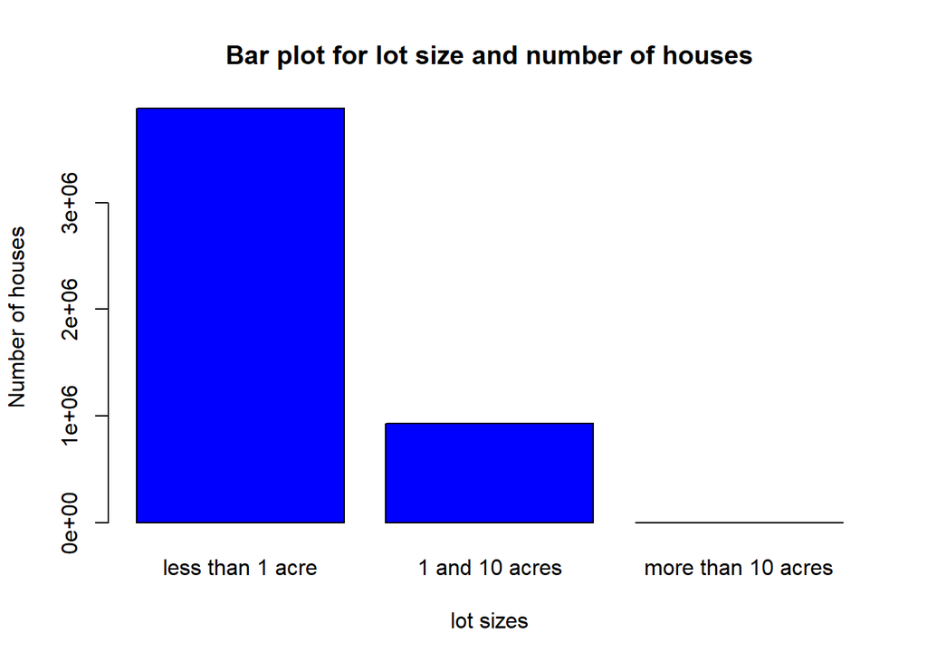

```r
#Finding the number of houses on a lot less than one acre
lot1 <- length(h_abcd$SERIALNO[h_abcd$ACR == 1])
#Finding the number of houses on a lot between 1 to 10 acres
lot2 <- length(h_abcd$SERIALNO[h_abcd$ACR == 2])
#Finding the number of houses on a lot size greater than or equal to 10 acres
lot3 <- length(h_abcd$SERIALNO[h_abcd$ACR == 3])
#Making a dataframe out of all 3
lot.all <- c(lot1,lot2,lot3)
matrix.lot <- matrix(data=lot.all, nrow = 1, ncol=3, byrow=TRUE)
rownames(matrix.lot) <- c("Number of houses")
colnames(matrix.lot) <- c("less than 1 acre", "1 and 10 acres", "more than 10 acres")
barplot(matrix.lot, col="Blue", main="Bar plot for lot size and number of houses", xlab="lot sizes", ylab="Number of houses", width=c(2,2))
```

Hence, the graph shows that a majority of the houses are built on a less than one acre land. There are some houses built on a land with lot size between 1 and 10 acres but no houses on a lot size of more than 10 acres.

We now try to find the number of houses according to the number of people living in it.

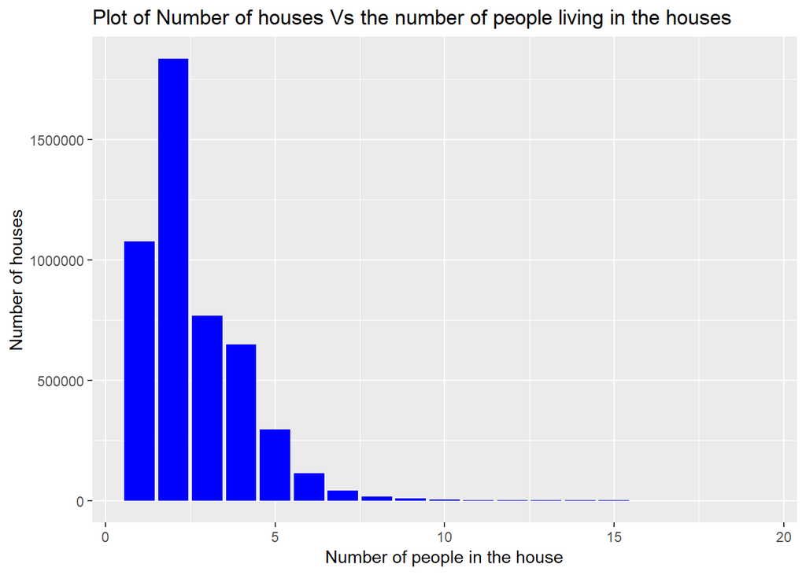

```r
aggr_data <- aggregate(h_abcd$SERIALNO, by=list(Number_of_people=h_abcd$NP), FUN=length)
ggplot(data=aggr_data, aes(x=Number_of_people, y=x))+
  geom_bar(stat="identity", fill="blue")+
  ggtitle("Plot of Number of houses Vs the number of people living in the houses")+
  xlab("Number of people in the house")+
  ylab("Number of houses")
```

Now we try to see if the number of people living in the house has a relationship with the monthly electricity cost of the house.

```r
aggr_data_cost <- aggregate(h_abcd$ELEP_A, by=list(Number_of_people=h_abcd$NP), FUN=mean)
colnames(aggr_data_cost) <- c("Number_of_people", "Average_electricity_Cost")
aggr_data_cost
```

| Number_of_people | Average_electricity_Cost |
| --- | --- |
| 1 | 115651625 |
| 2 | 150113368 |
| 3 | 170009144 |
| 4 | 182500390 |
| 5 | 193918089 |
| 6 | 199796838 |
| 7 | 207922741 |
| 8 | 213541010 |
| 9 | 217577997 |
| 10 | 225251096 |

[output cut: 9 more lines]

We can also check if there is any relationship between the number of people living in the house (NP) and the number of bedrooms in the house. For this, we use the **spearman correlation test** in R. The null hypothesis is **The data is linearly independent.** and alternate hypothesis is **the data is linearly dependent**. The code is as follows,

```r
cor.test(h_abcd$NP, h_abcd$BDSP, method="spearman")
```

```
##
##  Spearman's rank correlation rho
##
## data:  h_abcd$NP and h_abcd$BDSP
## S = 1.1145e+14, p-value < 2.2e-16
## alternative hypothesis: true rho is not equal to 0
## sample estimates:
##      rho
## 0.999994
```

According to the above test result, the p-value is very less than 0.05 significance level. Hence, we reject the null hypothesis and conclude that there is a relationship between the number of people living in the house and the number of bedrooms in the house. We see that the value for rho is almost 1. Hence, we can say that there is a positive correlation between the two variables. We analyse this relationship further in the findings section.

## Findings

As per the graphs in the methodology section, we see that majority of the houses are built on land less than one acre and most of the houses have 2 people living in the house. So now, we can find the number of houses on less than one acre having two people living in the house.

The code is as follows,

```r
#Filtering the number of people with houses on less than one acre and 2 people in the house
ACR1_NP2 <- h_abcd %>%
  filter(ACR==1 & NP == 2)
#Finding the count of those records
c1 <- length(ACR1_NP2$SERIALNO)
#Finding the count of all the records
c2 <- length(h_abcd$SERIALNO)
#Finding the proportion
proportion <- c1/c2
proportion
```

```
## [1] 0.3006701
```

So it looks like 30.0670077% have houses on less than one acre and number of people living in the house as 2. This is a pretty large number of houses. So we can say that a significant number of the population are either a couple, married or two tenants living together. We can leave this analysis for the future when there is more informtation about the relationships between the two people living together.

For now, we can compare the water costs and electricity costs paid by the population of the above proportion.

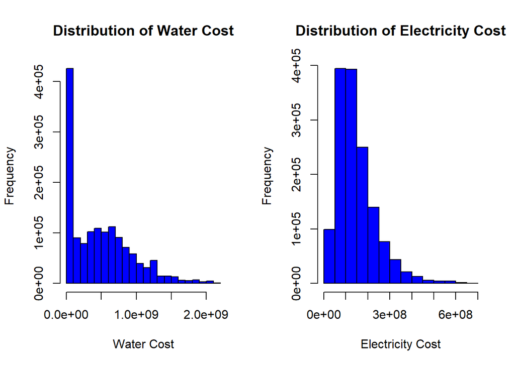

```r
#Selecting cost of  water and electricity for the above discussed proportion of population
for_graph <- ACR1_NP2 %>%
  select(ACR,NP,WATP_A, ELEP_A)
#Visualising it
par(mfrow=c(1,2))
hist(x=for_graph$WATP_A, main="Distribution of Water Cost", xlab="Water Cost", ylab="Frequency", col="blue")
hist(x=for_graph$ELEP_A, main="Distribution of Electricity Cost", xlab="Electricity Cost", ylab="Frequency", col="blue")
```

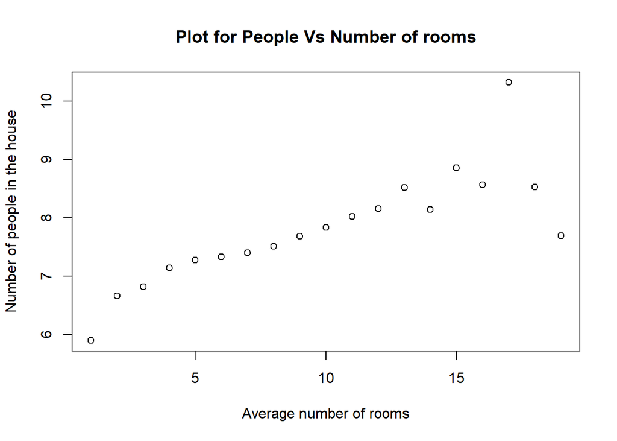

```r
aggr_data_rooms <- aggregate(h_abcd$RMSP, by=list(Number_of_people=h_abcd$NP), FUN=mean)
colnames(aggr_data_rooms) <- c("Number_of_people", "Average_number_of_rooms")
plot(aggr_data_rooms, main="Plot for People Vs Number of rooms", xlab="Average number of rooms",  ylab="Number of people in the house")
```

Looking at the above graph, it is quite surprising to see that even though there is only one person living in the house, the average number of rooms in the house is 5.8965179. Likewise, the average number of rooms in the house with two people is 6.6654071.This might be the reason for more monthly electricity cost for houses with two people. So, people are on average living in houses that have more number of rooms than the actual people living in the house.

We also find the average number of bedrooms in the house corresponding to the number of people living in the house.

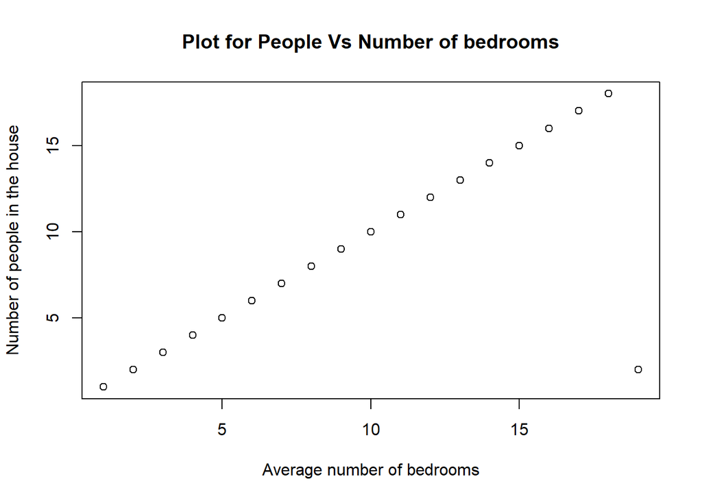

```r
aggr_data_bedrooms <- aggregate(h_abcd$BDSP, by=list(Number_of_people=h_abcd$NP), FUN=mean)
colnames(aggr_data_bedrooms) <- c("Number_of_people", "Average_number_of_bedrooms")
plot(aggr_data_bedrooms, main="Plot for People Vs Number of bedrooms", xlab="Average number of bedrooms",  ylab="Number of people in the house")
```

The above graph shows that there is a good linear trend between the number of people living in the house and the number of bedrooms. There is one particular data point which is interesting in the graph. It is at the bottom right corner. It is the observation that shows that there are 19 people living in the house but only 2 bedrooms. So now we remove that data point and see if there is any change in the trend.

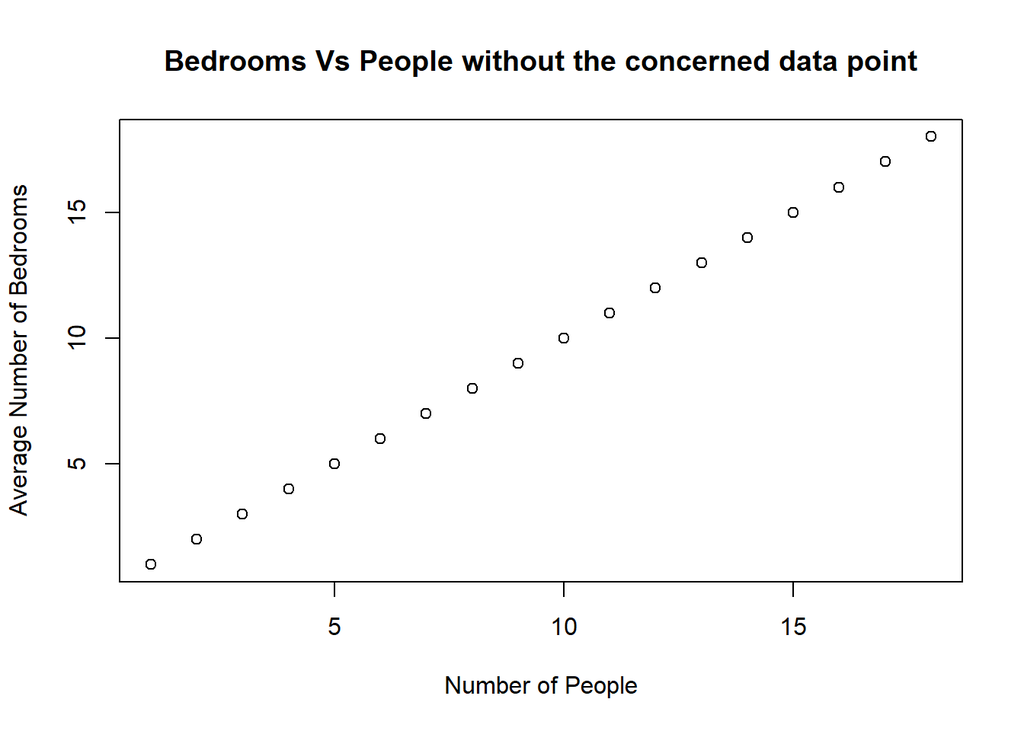

```r
aggr_data_bedrooms1 <- aggr_data_bedrooms[-19,]
plot(aggr_data_bedrooms1, main="Bedrooms Vs People without the concerned data point", xlab="Number of People", ylab="Average Number of Bedrooms")
```

The above graph shows the trend after removing the concerned datapoint. It looks like that there is not any difference in the overall trend of the number of bedrooms according to to the number of people living in the house. Removing that data doesn’t have any difference on the analysis.

In the table of the methodology section we found that there is something interesting between the number of people living in the house and the monthly electricity cost incurred. So let’s do further analysis on it.

```r
#Find number of houses with 19 people living in the house
length(h_abcd$SERIALNO[h_abcd$NP==19])
```

```
## [1] 13
```

```r
#Tranforming ELEP_A to its square root
ELEP_A1 <- sqrt(h_abcd$ELEP_A)
model1 <- lm(ELEP_A1 ~ BDSP+WATP_A+NP+ACR, h_abcd)
summary(model1)
```

```
##
## Call:
## lm(formula = ELEP_A1 ~ BDSP + WATP_A + NP + ACR, data = h_abcd)
##
## Residuals:
##      Min       1Q   Median       3Q      Max
## -20535.3  -2386.7   -252.9   2213.6  15470.6
##
## Coefficients:
##              Estimate Std. Error  t value Pr(>|t|)
## (Intercept) 8.354e+03  6.666e+00 1253.298  < 2e-16 ***
## BDSP        4.565e+02  6.580e+01    6.938 3.98e-12 ***
## WATP_A      8.179e-07  3.872e-09  211.207  < 2e-16 ***
## NP          1.791e+02  6.579e+01    2.723  0.00647 **
## ACR         1.194e+03  4.413e+00  270.643  < 2e-16 ***
## ---
## Signif. codes:  0 '***' 0.001 '**' 0.01 '*' 0.05 '.' 0.1 ' ' 1
##
## Residual standard error: 3710 on 4741837 degrees of freedom
##   (70293 observations deleted due to missingness)
## Multiple R-squared:  0.08092,    Adjusted R-squared:  0.08092
## F-statistic: 1.044e+05 on 4 and 4741837 DF,  p-value: < 2.2e-16
```

```r
#For extracting the p-value in the inline code
model1.coef <- summary(model1)$coef
```

Looking at the summary of the model, lets now interrept the various aspects of the model,

**Formula Call** : The function that gives the formula that was used to create the model.

**Residuals** : It is basically the difference between the actual value of the response variable and the values of the response variables that the model predicted. Looking at our residuals, it is seen that the residuals are distributed approximately normally.

**Coefficients** : The constants in a simple linear regression model represent the slope and the intercept terms such that the resultant fitted line is closer to the data points in our dataset. The **estimated coefficient** is the **intercept and slopes**. In our model, it represents the expected value of the square root of the cost of eletricity(Since we transformed ELEP_A to its square root) when all the explanatory variables are 0; that is, when there are no people living in the house, when the lot size is 0, when the water cost is 0 and when the number of bedrooms is also 0.

The **second, third, fourth and fifth rows** give the **slope**. For BDSP, the slope is 456.5374854.This means that for every 1 bedroom addition in the house, the cost of electricity goes up by 456.5374854.For, WATP_A, the slope is 8.178538110^{-7}. This means that This means that for every 1 dollar increase in the cost of water, the cost of electricity goes up by 8.178538110^{-7}. For NP, the slope is 179.1472167.This means that for every 1 additional person in the house, the cost of electricity goes up by 179.1472167. For, ACR, the slope is 1194.3743455. This means that This means that for every 1 acre increase in the size of the lot, the cost of electricity goes up by 1194.3743455. In all the above cases, to get the actual increase in the electricity cost, we have to square it because we have applied square root transformation to it.

**The standard error** gives the average amounts by which the coefficient estimates vary from the actual average value of our response variable(The electricity cost). In our model, it looks like the values of standard errors are pretty large and hence, we could say that the predicted values may not be reliable for this regression.

**The t-value** measures the amount by which our standard deviations of the coefficient estimates are away from 0. Since, in all the cases, the t-value is away from 0, we can say that there is a relationship between the cost of electricity and number of people, lot size, water cost and number of bedrooms.

**The p-value** gives the probability of observing any value that is greater than or equal to t. The p-values for BDSP, WATP_A, NP and ACR are 3.983888810^{-12}, 0, 0.0064725, 0 respectively. Since, all the p-values are less than 0.05 significance level, we can conclude that there is a significant relationship between all of our explanatory variables and our response variable.

**Residual Standard error** gives the quality of the regression fit and gives the amount by which the predicted value of the response variable will deviate from the true regression line. In our model, the residual standard error is 3710. So we can say that the actual electricity cost may deviate from the true regression line by 3710 dollars on average.

**F-statistic** is also a good indicator to find the relationship between response and the predictor variables. For our model, the f-value is 104376.9. Since, our value is very large than 1, we can reject the null hypothesis which says that there is no relationhip between the concerned variables and we can thus conclude that there is a relationship between the response and explanatory variables.

**P-value of the f-statistic** : Since, our p-value is 2.2e-16 which is very less than 0.05, we can say that our model is a bettern regression fit than an intercept only model.

The diagnostic plots of the regression model are as follows:

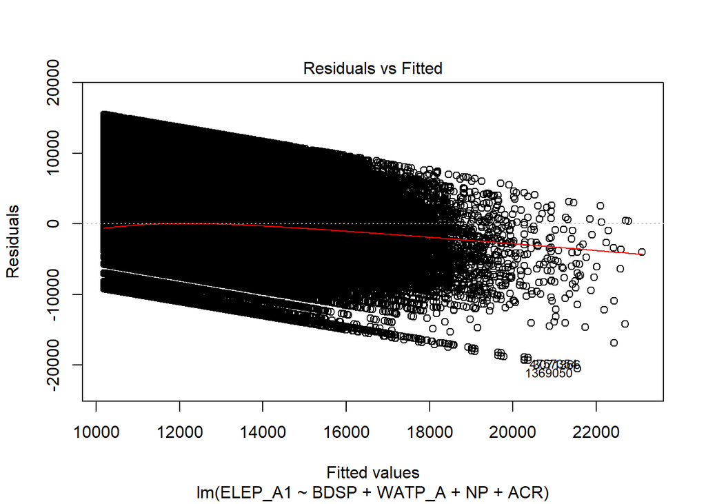

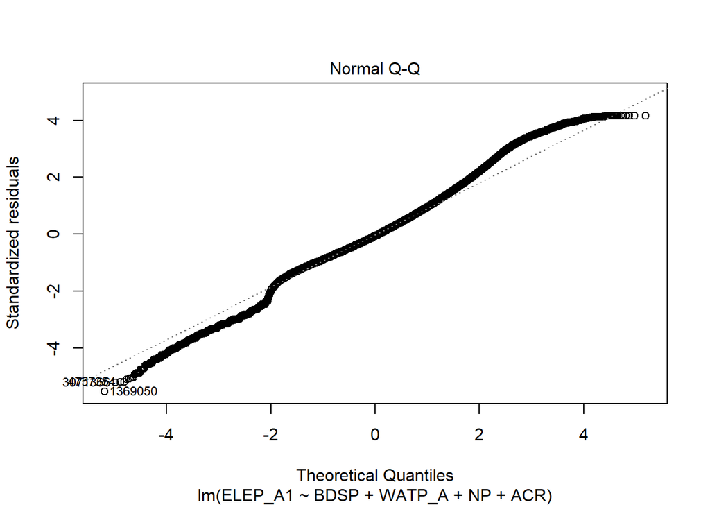

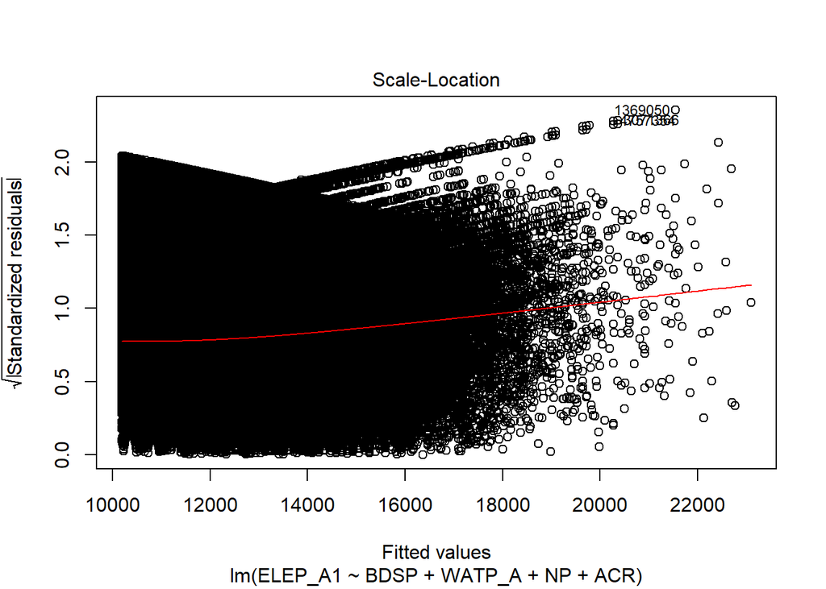

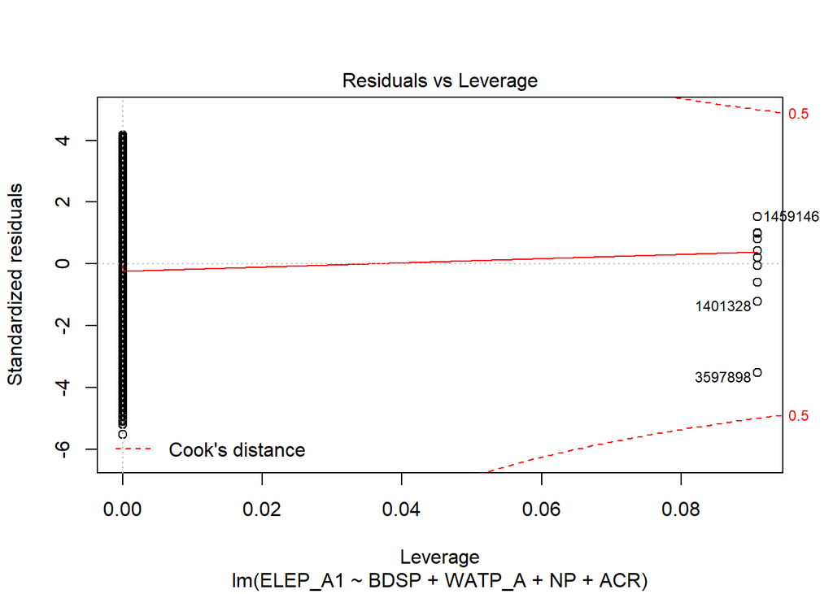

```r
plot(model1)
```

**Interpretation of the diagnostic plots:**

**Scale-Location Plot** : It indicates the spread of the data points across the range of predicted values. The red line indicates that the residuals have uniform variance across the range. With this plot, we check the data for Homoscedasticity. (i.e variance should be reasonably equal across the predictor range). In our plot, the red line is reasonably horizontal except for the end where it goes a little up. Hence, at the right of the plot, we see that the residuals are spread wider. Hence, the property of does not hold for Homoscedasticity our model.

**Residuals Vs. Leverage** : This plot is used to find any influential observations that can influence the results of the regression model. For this, it uses the Cook’s distance. The dotted red lines are the cook’s distance and we consider a case as an influential case if it lies beyond the dotted red lines in the upper and the bottom right corner. In our plot, there are no points lying beyond the dotted red lines. Hence, we can say that there are no influential observations in the data.

## Discussion

I have about 40% confidence in the analysis that I have done above and I would surely revise it if I have to present it to the policy makers. I do believe in the conclusions that I have reached but there could be certain aspects in the data that I could have failed to account for. For this reason, I would definitely revise it if I get a chance to present this analysis to the policy makers.

## Appendix

1. Given below is the code for creating, loading and exporting the new .csv file containing only the data that I used for my analysis:

```r
#loading Housing file A with relevant attributes
ha <- fread("E:/neha/studies/trent study material/Data Analysis with R/ss16husa.csv")
ha <- ha %>%
  select(RT, SERIALNO, ADJHSG, NP, ACR, BATH, BDSP, ELEP, WATP, REFR, RMSP, RWAT)
head(ha)

#loading Housing file B with relevant attributes
hb <- fread("E:/neha/studies/trent study material/Data Analysis with R/ss16husb.csv")
hb <- hb %>%
  select(RT, SERIALNO, ADJHSG, NP, ACR, BATH, BDSP, ELEP, WATP, REFR, RMSP, RWAT)
head(hb)

#loading Housing file C with relevant attributes
hc <- fread("E:/neha/studies/trent study material/Data Analysis with R/ss16husc.csv")
hc <- hc %>%
  select(RT, SERIALNO, ADJHSG, NP, ACR, BATH, BDSP, ELEP, WATP, REFR, RMSP, RWAT)
head(hc)

#loading Housing file D with relevant attributes
hd <- fread("E:/neha/studies/trent study material/Data Analysis with R/ss16husd.csv")
hd <- hd %>%
  select(RT, SERIALNO, ADJHSG, NP, ACR, BATH, BDSP, ELEP, WATP, REFR, RMSP, RWAT)
head(hd)

#Binding all the dataframes and then ordering the data according to SERIAL NUMBER
h_all <- do.call("rbind", list(ha,hb,hc,hd))
head(h_all)
h_all <- h_all[order(h_all$SERIALNO),]

#Exporting the created dataframe as a .csv file
write.csv(h_all, file = "E:/neha/studies/trent study material/Data Analysis with R/housing_all.csv")

#Reading that exported file. This file is used for the analysis.
h_abcd <- fread("E:/neha/studies/trent study material/Data Analysis with R/housing_all.csv")
head(h_abcd)
```

2. Reference link for the plot of missing values: https://datascienceplus.com/imputing-missing-data-with-r-mice-package/
3. The outliers package documentation : https://cran.r-project.org/web/packages/outliers/outliers.pdf
4. Code for bathrooms, refrigerators and running hot/cold water,

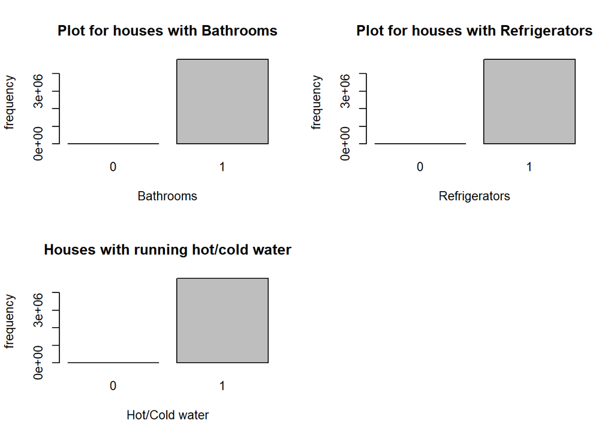

```r
par(mfrow=c(2,2))
plot(h_abcd$BATH, main="Plot for houses with Bathrooms", xlab="Bathrooms", ylab="frequency")
plot(h_abcd$REFR, main="Plot for houses with Refrigerators", xlab="Refrigerators", ylab="frequency")
plot(h_abcd$RWAT, main="Houses with running hot/cold water", xlab="Hot/Cold water", ylab="frequency")
```

5. Code for plot of water and electricity cost with the corresponding variables.

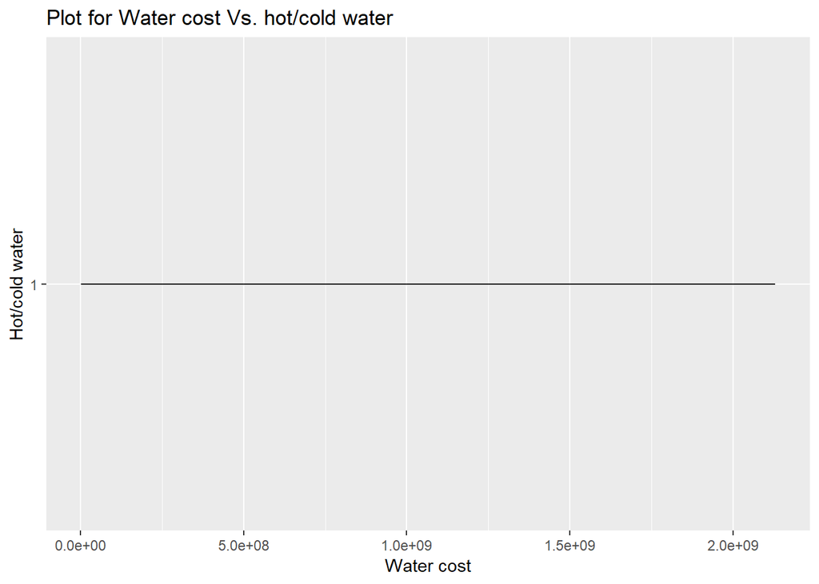

```r
h_abcd1 <- h_abcd
h_abcd1 %>%
group_by(RWAT, WATP_A) %>%
  select(RWAT, WATP_A) %>%
  ggplot(aes(x=WATP_A, y=RWAT))+
  geom_line()+
  ggtitle("Plot for Water cost Vs. hot/cold water")+
  xlab("Water cost")+
  ylab("Hot/cold water")
```

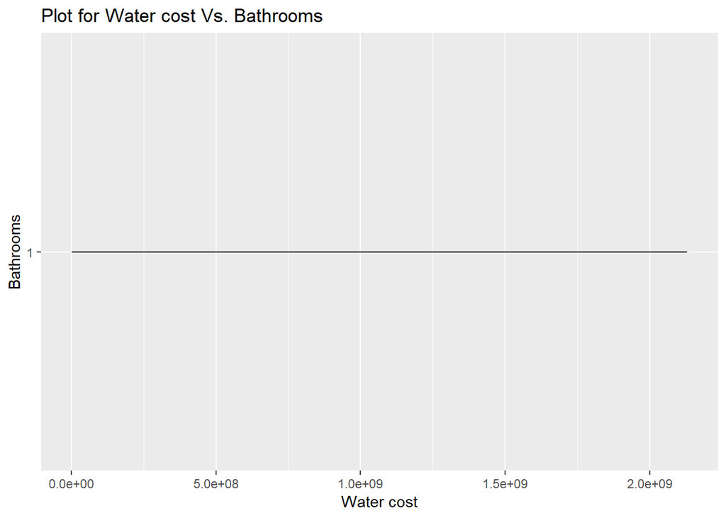

```r
h_abcd2 <- h_abcd
h_abcd2 %>%
group_by(BATH, WATP_A) %>%
  select(BATH, WATP_A) %>%
  ggplot(aes(x=WATP_A, y=BATH))+
  geom_line()+
  ggtitle("Plot for Water cost Vs. Bathrooms")+
  xlab("Water cost")+
  ylab("Bathrooms")
```

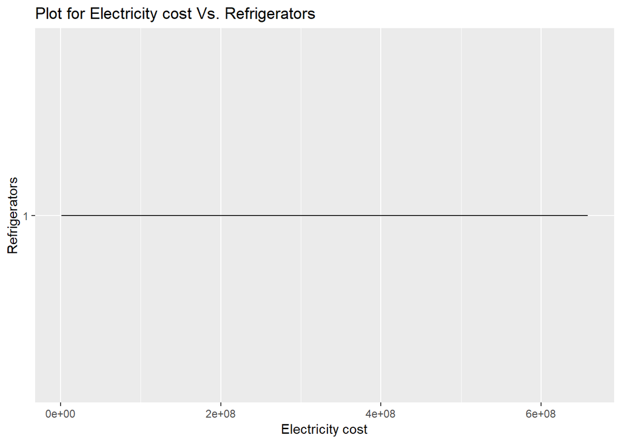

```r
h_abcd3 <- h_abcd
h_abcd3 %>%
group_by(REFR, ELEP_A) %>%
  select(REFR, ELEP_A) %>%
  ggplot(aes(x=ELEP_A, y=REFR))+
  geom_line()+
  ggtitle("Plot for Electricity cost Vs. Refrigerators")+
  xlab("Electricity cost")+
  ylab("Refrigerators")
```